# Air BnB Data Analysis

# Research Question 1: What variables contribute to a customer’s complete satisfaction with a hotel?

### EDA

```r
AirBnb.data %>%
  group_by(satisfaction) %>%
  summarise(mean(bedrooms),
            mean(accommodates),
            mean(price),
            mean(minstay),
            mean(WalkScore),
            mean(TransitScore),
            mean(BikeScore))
```

```
## # A tibble: 2 x 8
##   satisfaction `mean(bedrooms)` `mean(accommoda~ `mean(price)`
##   <fct>                   <dbl>            <dbl>         <dbl>
## 1 0                        1.43             3.88          102.
## 2 1                        1.37             3.39          114.
## # ... with 4 more variables: `mean(minstay)` <dbl>,
## #   `mean(WalkScore)` <dbl>, `mean(TransitScore)` <dbl>,
## #   `mean(BikeScore)` <dbl>
```

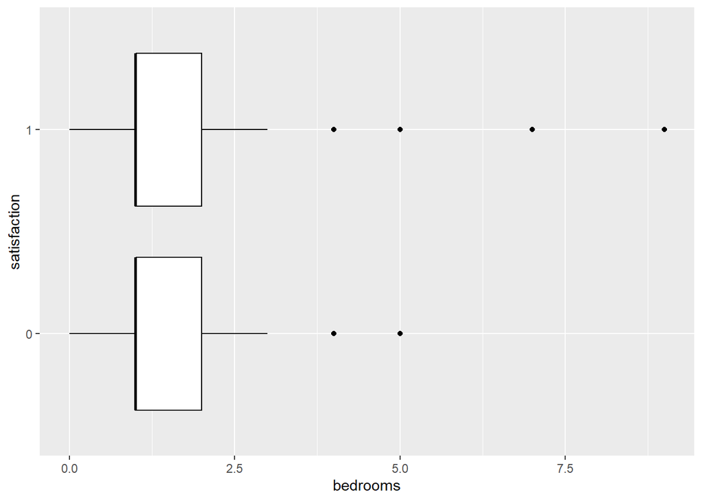

```r
ggplot(AirBnb.data, aes(x = satisfaction, y = bedrooms)) + geom_boxplot(color = "black") + coord_flip()
```

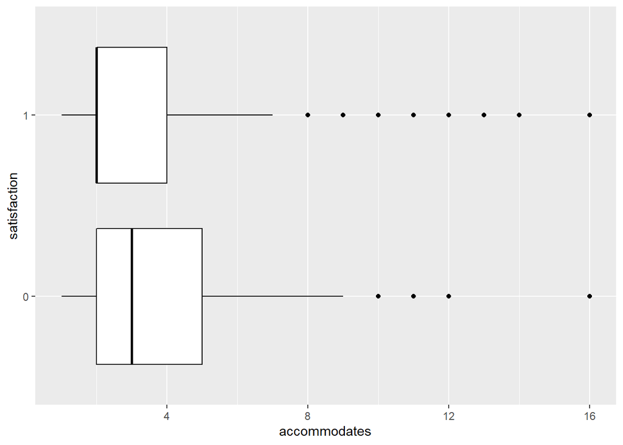

```r
ggplot(AirBnb.data, aes(x = satisfaction, y = accommodates)) + geom_boxplot(color = "black") + coord_flip()
```

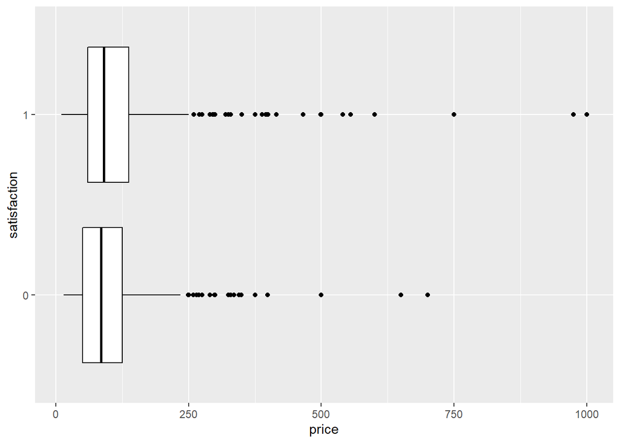

```r
ggplot(AirBnb.data, aes(x = satisfaction, y = price)) + geom_boxplot(color = "black") + coord_flip()
```

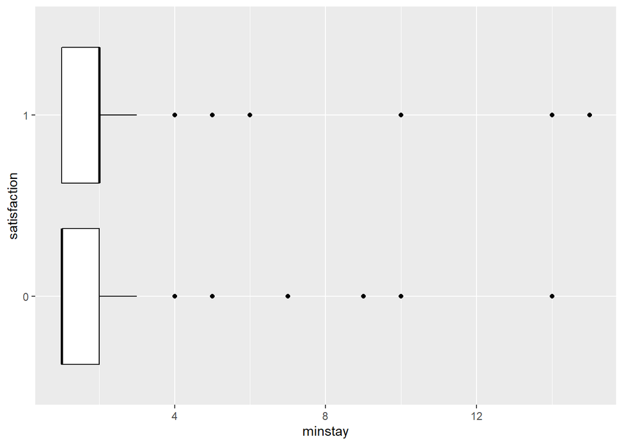

```r
ggplot(AirBnb.data, aes(x = satisfaction, y = minstay)) + geom_boxplot(color = "black") + coord_flip()
```

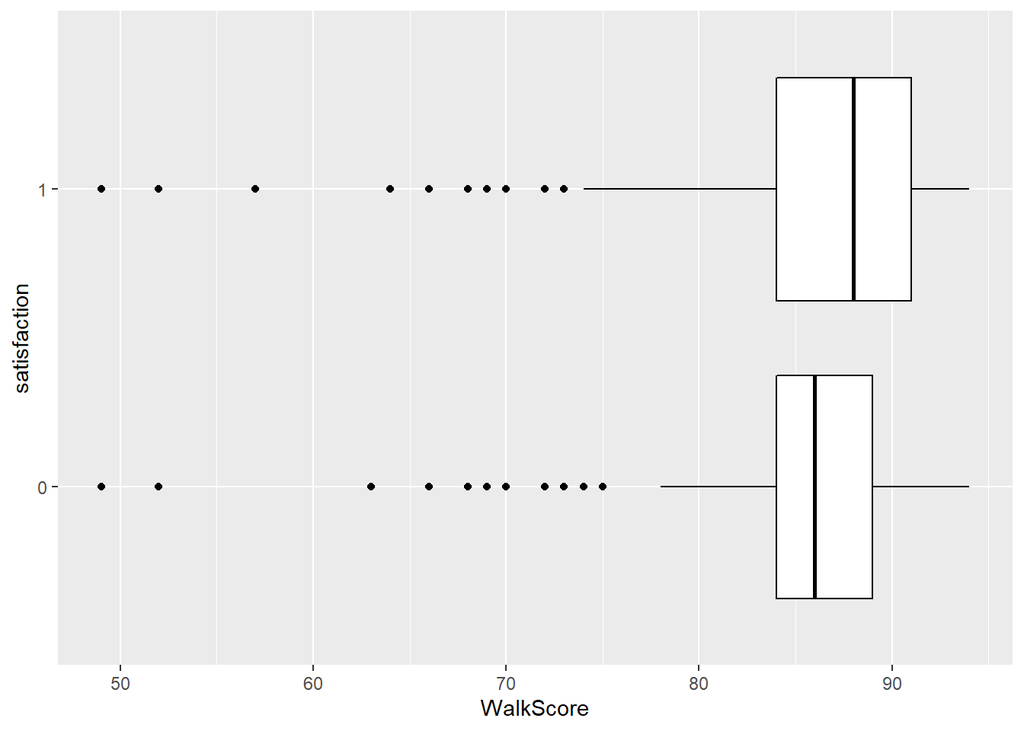

```r
ggplot(AirBnb.data, aes(x = satisfaction, y = WalkScore)) + geom_boxplot(color = "black") + coord_flip()
```

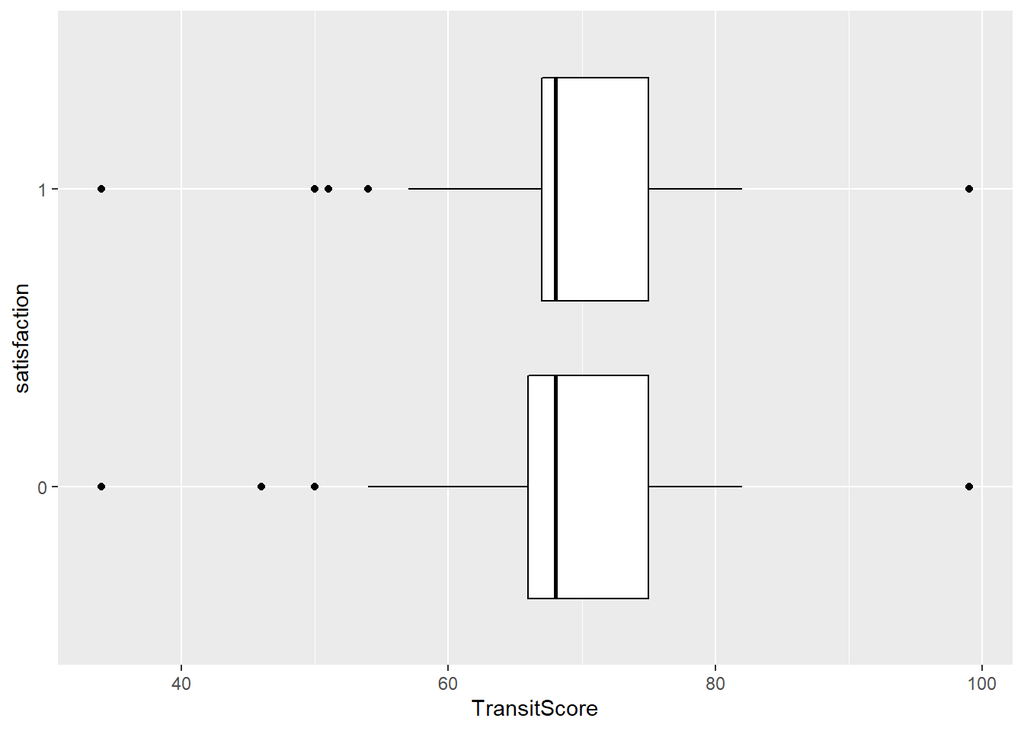

```r
ggplot(AirBnb.data, aes(x = satisfaction, y = TransitScore)) + geom_boxplot(color = "black") + coord_flip()
```

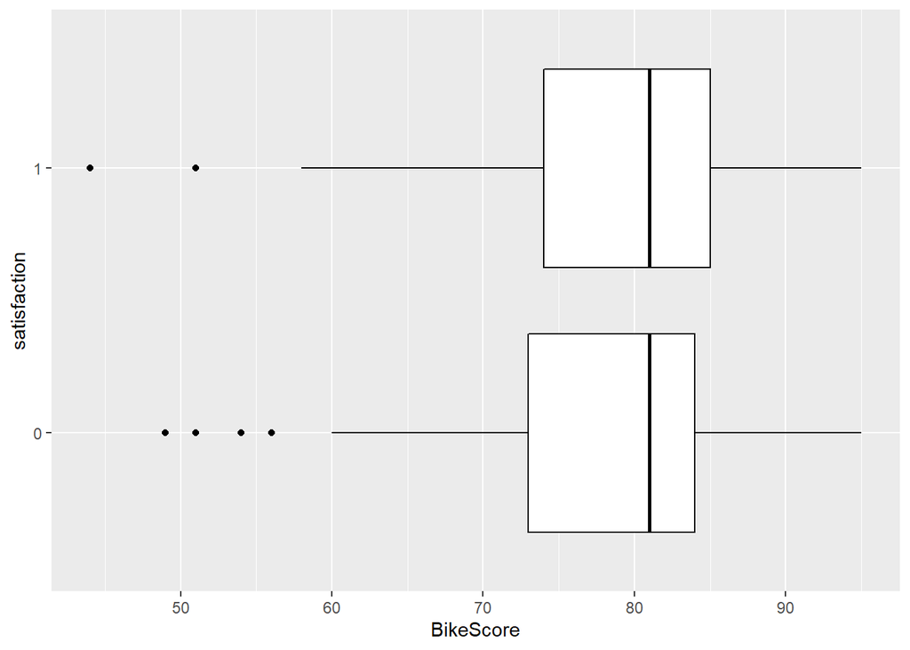

```r
ggplot(AirBnb.data, aes(x = satisfaction, y = BikeScore)) + geom_boxplot(color = "black") + coord_flip()
```

### Fitting the Models for Research Question 1

- First I tested each variable (bedrooms, accommodates, price, minstay, WalkScore, TransitScore and BikeScore) to see if they were significant in predicting the odds that a customer is satisfied with their stay at their hotel. After fitting each model, it appeared that the significant variables were accommodates, price and WalkScore. Then, I decided to create a full model which would contain the additive model of the significant variables as well as their interactions. After the backwards elimination process, the full final model turned out to be:

$$log(pi/(1−pi)) = \beta_0 + \beta_1(accommodates) + \beta_2(price) + \beta_3(WalkScore) + \beta_4(accommodates*WalkScore) + \beta_5(price*WalkScore)$$

```r
# Bedtooms
bedModel <- glm(satisfaction ~ bedrooms, family = "binomial", data = AirBnb.data)
summary(bedModel)
```

```
##
## Call:
## glm(formula = satisfaction ~ bedrooms, family = "binomial", data = AirBnb.data)
##
## Deviance Residuals:
##     Min       1Q   Median       3Q      Max
## -1.4312  -1.3855   0.9827   0.9827   1.3254
##
## Coefficients:
##             Estimate Std. Error z value Pr(>|z|)
## (Intercept)  0.57935    0.10577   5.477 4.31e-08 ***
## bedrooms    -0.10231    0.06554  -1.561    0.119
## ---
## Signif. codes:  0 '***' 0.001 '**' 0.01 '*' 0.05 '.' 0.1 ' ' 1
##
## (Dispersion parameter for binomial family taken to be 1)
##
##     Null deviance: 2091.6  on 1560  degrees of freedom
## Residual deviance: 2089.1  on 1559  degrees of freedom
## AIC: 2093.1
##
## Number of Fisher Scoring iterations: 4
```

```r
# Accomodations
accModel <- glm(satisfaction ~ accommodates, family = "binomial", data = AirBnb.data)
summary(accModel)
```

```
##
## Call:
## glm(formula = satisfaction ~ accommodates, family = "binomial",
##     data = AirBnb.data)
##
## Deviance Residuals:
##     Min       1Q   Median       3Q      Max
## -1.4731  -1.3520   0.9421   0.9769   1.4780
##
## Coefficients:
##              Estimate Std. Error z value Pr(>|z|)
## (Intercept)   0.76315    0.09663   7.898 2.83e-15 ***
## accommodates -0.09041    0.02234  -4.047 5.19e-05 ***
## ---
## Signif. codes:  0 '***' 0.001 '**' 0.01 '*' 0.05 '.' 0.1 ' ' 1
##
## (Dispersion parameter for binomial family taken to be 1)
##
##     Null deviance: 2091.6  on 1560  degrees of freedom
## Residual deviance: 2075.0  on 1559  degrees of freedom
## AIC: 2079
##
## Number of Fisher Scoring iterations: 4
```

```r
# Price
priceModel <- glm(satisfaction ~ price, family = "binomial", data = AirBnb.data)
summary(priceModel)
```

```
##
## Call:
## glm(formula = satisfaction ~ price, family = "binomial", data = AirBnb.data)
##
## Deviance Residuals:
##     Min       1Q   Median       3Q      Max
## -1.8415  -1.3344   0.9658   1.0203   1.0684
##
## Coefficients:
##              Estimate Std. Error z value Pr(>|z|)
## (Intercept) 0.2440751  0.0868919   2.809  0.00497 **
## price       0.0017838  0.0006605   2.701  0.00692 **
## ---
## Signif. codes:  0 '***' 0.001 '**' 0.01 '*' 0.05 '.' 0.1 ' ' 1
##
## (Dispersion parameter for binomial family taken to be 1)
##
##     Null deviance: 2091.6  on 1560  degrees of freedom
## Residual deviance: 2083.5  on 1559  degrees of freedom
## AIC: 2087.5
##
## Number of Fisher Scoring iterations: 4
```

```r
# Minimum stay
minstayModel <- glm(satisfaction ~ minstay, family = "binomial", data = AirBnb.data)
summary(minstayModel)
```

```
##
## Call:
## glm(formula = satisfaction ~ minstay, family = "binomial", data = AirBnb.data)
##
## Deviance Residuals:
##     Min       1Q   Median       3Q      Max
## -1.3777  -1.3637   0.9895   1.0019   1.1700
##
## Coefficients:
##             Estimate Std. Error z value Pr(>|z|)
## (Intercept)  0.49104    0.09406   5.221 1.78e-07 ***
## minstay     -0.03156    0.04349  -0.726    0.468
## ---
## Signif. codes:  0 '***' 0.001 '**' 0.01 '*' 0.05 '.' 0.1 ' ' 1
##
## (Dispersion parameter for binomial family taken to be 1)
##
##     Null deviance: 1906.8  on 1422  degrees of freedom
## Residual deviance: 1906.3  on 1421  degrees of freedom
##   (138 observations deleted due to missingness)
## AIC: 1910.3
##
## Number of Fisher Scoring iterations: 4
```

```r
# Walk Score
minstayModel <- glm(satisfaction ~ WalkScore, family = "binomial", data = AirBnb.data)
summary(minstayModel)
```

```
##
## Call:
## glm(formula = satisfaction ~ WalkScore, family = "binomial",
##     data = AirBnb.data)
##
## Deviance Residuals:
##     Min       1Q   Median       3Q      Max
## -1.4427  -1.3699   0.9568   0.9964   1.3123
##
## Coefficients:
##              Estimate Std. Error z value Pr(>|z|)
## (Intercept) -1.309583   0.679064  -1.929  0.05379 .
## WalkScore    0.020367   0.007905   2.576  0.00998 **
## ---
## Signif. codes:  0 '***' 0.001 '**' 0.01 '*' 0.05 '.' 0.1 ' ' 1
##
## (Dispersion parameter for binomial family taken to be 1)
##
##     Null deviance: 2091.6  on 1560  degrees of freedom
## Residual deviance: 2084.9  on 1559  degrees of freedom
## AIC: 2088.9
##
## Number of Fisher Scoring iterations: 4
```

```r
# Transit Score
minstayModel <- glm(satisfaction ~ TransitScore, family = "binomial", data = AirBnb.data)
summary(minstayModel)
```

```
##
## Call:
## glm(formula = satisfaction ~ TransitScore, family = "binomial",
##     data = AirBnb.data)
##
## Deviance Residuals:
##     Min       1Q   Median       3Q      Max
## -1.3891  -1.3663   0.9960   0.9991   1.0131
##
## Coefficients:
##               Estimate Std. Error z value Pr(>|z|)
## (Intercept)   0.529732   0.397656   1.332    0.183
## TransitScore -0.001314   0.005524  -0.238    0.812
##
## (Dispersion parameter for binomial family taken to be 1)
##
##     Null deviance: 2091.6  on 1560  degrees of freedom
## Residual deviance: 2091.5  on 1559  degrees of freedom
## AIC: 2095.5
##
## Number of Fisher Scoring iterations: 4
```

```r
# Bike Score
minstayModel <- glm(satisfaction ~ BikeScore, family = "binomial", data = AirBnb.data)
summary(minstayModel)
```

```
##
## Call:
## glm(formula = satisfaction ~ BikeScore, family = "binomial",
##     data = AirBnb.data)
##
## Deviance Residuals:
##     Min       1Q   Median       3Q      Max
## -1.4111  -1.3701   0.9757   0.9962   1.0942
##
## Coefficients:
##              Estimate Std. Error z value Pr(>|z|)
## (Intercept) -0.090429   0.507118  -0.178    0.858
## BikeScore    0.006578   0.006307   1.043    0.297
##
## (Dispersion parameter for binomial family taken to be 1)
##
##     Null deviance: 2091.6  on 1560  degrees of freedom
## Residual deviance: 2090.5  on 1559  degrees of freedom
## AIC: 2094.5
##
## Number of Fisher Scoring iterations: 4
```

```r
#Full Model
fullModel <- glm(satisfaction ~ (accommodates + price + WalkScore)^2, family = "binomial", data = AirBnb.data)

fullFinalModel <- step(fullModel, direction = "backward")
```

```
## Start:  AIC=2029.28
## satisfaction ~ (accommodates + price + WalkScore)^2
##
##                          Df Deviance    AIC
## - accommodates:price      1   2015.5 2027.5
## <none>                        2015.3 2029.3
## - accommodates:WalkScore  1   2018.3 2030.3
## - price:WalkScore         1   2026.0 2038.0
##
## Step:  AIC=2027.55
## satisfaction ~ accommodates + price + WalkScore + accommodates:WalkScore +
##     price:WalkScore
##
##                          Df Deviance    AIC
## <none>                        2015.5 2027.5
## - accommodates:WalkScore  1   2019.0 2029.0
## - price:WalkScore         1   2026.4 2036.4
```

```r
summary(fullFinalModel)
```

```
##
## Call:
## glm(formula = satisfaction ~ accommodates + price + WalkScore +
##     accommodates:WalkScore + price:WalkScore, family = "binomial",
##     data = AirBnb.data)
##
## Deviance Residuals:
##     Min       1Q   Median       3Q      Max
## -2.2259  -1.3136   0.8717   0.9736   2.0516
##
## Coefficients:
##                          Estimate Std. Error z value Pr(>|z|)
## (Intercept)            -1.7094179  1.4446266  -1.183 0.236693
## accommodates           -1.0877718  0.4725585  -2.302 0.021342 *
## price                   0.0592719  0.0168158   3.525 0.000424 ***
## WalkScore               0.0268196  0.0167342   1.603 0.109005
## accommodates:WalkScore  0.0099619  0.0054616   1.824 0.068157 .
## price:WalkScore        -0.0006085  0.0001893  -3.215 0.001306 **
## ---
## Signif. codes:  0 '***' 0.001 '**' 0.01 '*' 0.05 '.' 0.1 ' ' 1
##
## (Dispersion parameter for binomial family taken to be 1)
##
##     Null deviance: 2091.6  on 1560  degrees of freedom
## Residual deviance: 2015.5  on 1555  degrees of freedom
## AIC: 2027.5
##
## Number of Fisher Scoring iterations: 4
```

- Given that this is a somewhat of a complicated model with six parameter, two of which include an interaction between two variables, I wanted to test if the additive model would be sufficient in predicting the odds that the customer would be satisfied with their stay.
- Therefore:

$$H_0: log(pi/(1−pi)) = \beta_0 + \beta_1(accommodates) + \beta_2(price) + \beta_3(WalkScore)$$
$$H_a: log(pi/(1−pi)) = \beta_0 + \beta_1(accommodates) + \beta_2(price) + \beta_3(WalkScore) + \beta_4(accommodates*WalkScore) + \beta_5(price*WalkScore)$$

- The results of the likelihood ratio test were as follows: The LRT test statistic is 10.847 and the p-value is 0.004411. Because the p-value of 0.004411 is less than $\alpha$ = 0.05, we can reject the null and say that the interactions terms are significant in this model and should not be removed.

```r
redFinalModel <- glm(satisfaction ~ accommodates + price + WalkScore, family = "binomial", data = AirBnb.data)

lrtest(fullFinalModel, redFinalModel)
```

```
## Likelihood ratio test
##
## Model 1: satisfaction ~ accommodates + price + WalkScore + accommodates:WalkScore +
##     price:WalkScore
## Model 2: satisfaction ~ accommodates + price + WalkScore
##   #Df  LogLik Df  Chisq Pr(>Chisq)
## 1   6 -1007.8
## 2   4 -1013.2 -2 10.847   0.004411 **
## ---
## Signif. codes:  0 '***' 0.001 '**' 0.01 '*' 0.05 '.' 0.1 ' ' 1
```

- Therefore, the final model remains:

$$log(pi/(1−pi)) = \beta_0 + \beta_1(accommodates) + \beta_2(price) + \beta_3(WalkScore) + \beta_4(accommodates*WalkScore) + \beta_5(price*WalkScore)$$

### Conclusion:

- After looking at summary statistics and barplots, the seven variables I was interested in testing were bedrooms, accommodates, price, minstay, WalkScore, TransitScore, and BikeScore. I fit each variable in its own logistic regression model to see if they were significant in predicting the odds of complete satisfaction for customers. The final model created after backwards elimination contained the variables, accommodates, price, WalkScore, as well as the interactions accommodates * walkScore and price * WalkScore. To test if the model could be reduced to the just the additive model, I performed an LRT test; the results showed that the interactions were significant and should be kept in the model.